# Titanic_Regresion_Logística

```python
import os
os.chdir('C:\\Users\\GalindezR\\Desktop\\personal\\regresion_logistica_titanic\\data')
```

[figure not shown]

```python
from IPython.display import Image
Image("titanic.jpg")
```

La regresión logística nos permite predecir el valor de una variable dicotómica en función de unas variables independientes. En este caso la utilidad será predecir si un pasajero, dado un conjunto de variables asociadas a su viaje, sobreviviría o no al naufragio del Titanic.

Este método arroja un valor entre 0 y 1 para la variable Y (sobrevivencia del pasajero), por lo cual se establece un punto de corte de tal manera que si Y>= 0.5, quiere decir que ese pasajero sí sobreviviría y de lo contrario no.

**Importamos las librerias a usar**

```python
import pandas as pd
import numpy as np
import matplotlib.pyplot as plt
import seaborn as sns
```

**Definimos nuestro dataset de entrenamiento**

```python
entrenamiento = pd.read_csv('train.csv')
```

```python
entrenamiento.head()
```

|  | PassengerId | Survived | Pclass | Name | Sex | Age | SibSp | Parch | Ticket | Fare | Cabin | Embarked |
| --- | --- | --- | --- | --- | --- | --- | --- | --- | --- | --- | --- | --- |
| 0 | 1 | 0 | 3 | Braund, Mr. Owen Harris | male | 22.0 | 1 | 0 | A/5 21171 | 7.2500 | NaN | S |
| 1 | 2 | 1 | 1 | Cumings, Mrs. John Bradley (Florence Briggs Th... | female | 38.0 | 1 | 0 | PC 17599 | 71.2833 | C85 | C |
| 2 | 3 | 1 | 3 | Heikkinen, Miss. Laina | female | 26.0 | 0 | 0 | STON/O2. 3101282 | 7.9250 | NaN | S |
| 3 | 4 | 1 | 1 | Futrelle, Mrs. Jacques Heath (Lily May Peel) | female | 35.0 | 1 | 0 | 113803 | 53.1000 | C123 | S |
| 4 | 5 | 0 | 3 | Allen, Mr. William Henry | male | 35.0 | 0 | 0 | 373450 | 8.0500 | NaN | S |

**Análisis Exploratorio de Datos**

```python
entrenamiento.isnull()
```

|  | PassengerId | Survived | Pclass | Name | Sex | Age | SibSp | Parch | Ticket | Fare | Cabin | Embarked |
| --- | --- | --- | --- | --- | --- | --- | --- | --- | --- | --- | --- | --- |
| 0 | False | False | False | False | False | False | False | False | False | False | True | False |
| 1 | False | False | False | False | False | False | False | False | False | False | False | False |
| 2 | False | False | False | False | False | False | False | False | False | False | True | False |
| 3 | False | False | False | False | False | False | False | False | False | False | False | False |
| 4 | False | False | False | False | False | False | False | False | False | False | True | False |
| ... | ... | ... | ... | ... | ... | ... | ... | ... | ... | ... | ... | ... |
| 886 | False | False | False | False | False | False | False | False | False | False | True | False |
| 887 | False | False | False | False | False | False | False | False | False | False | False | False |
| 888 | False | False | False | False | False | True | False | False | False | False | True | False |
| 889 | False | False | False | False | False | False | False | False | False | False | False | False |
| 890 | False | False | False | False | False | False | False | False | False | False | True | False |

891 rows × 12 columns

Veamos qué variables tiene nulos para saber si imputamos o descartamos la variable para nuestro modelo

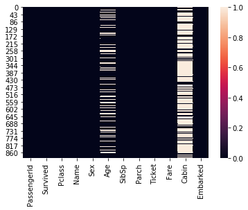

```python
sns.heatmap(entrenamiento.isnull())
```

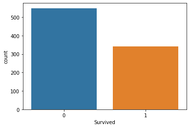

```python
sns.countplot(x='Survived',data=entrenamiento)
```

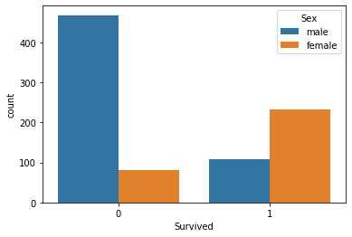

```python
sns.countplot(x='Survived',data=entrenamiento,hue='Sex')
```

```python
entrenamiento.columns
```

```
Index(['PassengerId', 'Survived', 'Pclass', 'Name', 'Sex', 'Age', 'SibSp',
       'Parch', 'Ticket', 'Fare', 'Cabin', 'Embarked'],
      dtype='object')
```

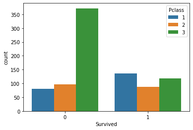

```python
sns.countplot(x='Survived',data=entrenamiento,hue='Pclass')
```

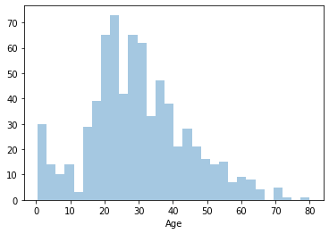

```python
sns.distplot(entrenamiento['Age'].dropna(),kde=False,bins=30)
```

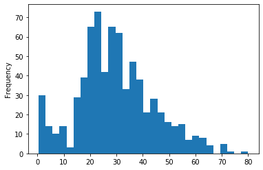

```python
entrenamiento['Age'].plot.hist(bins=30)
```

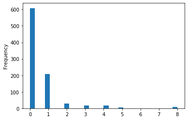

```python
entrenamiento['SibSp'].plot.hist(bins=30)
```

```python
import cufflinks as cf
```

```python
cf.go_offline()
```

```python
entrenamiento['Fare'].iplot(kind='hist',bins=40)
```

[interactive chart not shown]

**Limpieza de datos**

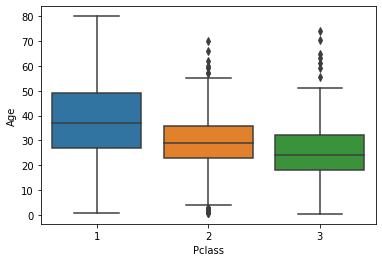

```python
sns.boxplot(x='Pclass',y='Age',data = entrenamiento)
```

```python
def edad_media(columnas):
    edad = columnas[0]
    clase = columnas[1]
    if pd.isnull(edad):
        if clase == 1:
            return 38
        elif clase == 2:
            return 30
        else:
            return 25
    else:
        return edad
```

```python
entrenamiento['Age'] = entrenamiento[['Age','Pclass']].apply(edad_media,axis=1)
# axis= 1 , para que lo aplique sobre las columnas
```

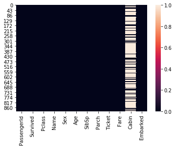

```python
sns.heatmap(entrenamiento.isnull())
```

```python
entrenamiento.drop('Cabin',axis=1,inplace=True)
```

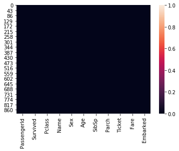

```python
sns.heatmap(entrenamiento.isnull())
```

```python
entrenamiento.head()
```

|  | PassengerId | Survived | Pclass | Name | Sex | Age | SibSp | Parch | Ticket | Fare | Embarked |
| --- | --- | --- | --- | --- | --- | --- | --- | --- | --- | --- | --- |
| 0 | 1 | 0 | 3 | Braund, Mr. Owen Harris | male | 22.0 | 1 | 0 | A/5 21171 | 7.2500 | S |
| 1 | 2 | 1 | 1 | Cumings, Mrs. John Bradley (Florence Briggs Th... | female | 38.0 | 1 | 0 | PC 17599 | 71.2833 | C |
| 2 | 3 | 1 | 3 | Heikkinen, Miss. Laina | female | 26.0 | 0 | 0 | STON/O2. 3101282 | 7.9250 | S |
| 3 | 4 | 1 | 1 | Futrelle, Mrs. Jacques Heath (Lily May Peel) | female | 35.0 | 1 | 0 | 113803 | 53.1000 | S |
| 4 | 5 | 0 | 3 | Allen, Mr. William Henry | male | 35.0 | 0 | 0 | 373450 | 8.0500 | S |

Excluimos aquellas variables que por su naturaleza no usaremos en nuestro modelo:

```
* Name
* Ticket
* PassengerId
```

```python
entrenamiento.drop(['Name','Ticket','PassengerId'],axis = 1, inplace = True)
```

```python
entrenamiento.head()
```

|  | Survived | Pclass | Sex | Age | SibSp | Parch | Fare | Embarked |
| --- | --- | --- | --- | --- | --- | --- | --- | --- |
| 0 | 0 | 3 | male | 22.0 | 1 | 0 | 7.2500 | S |
| 1 | 1 | 1 | female | 38.0 | 1 | 0 | 71.2833 | C |
| 2 | 1 | 3 | female | 26.0 | 0 | 0 | 7.9250 | S |
| 3 | 1 | 1 | female | 35.0 | 1 | 0 | 53.1000 | S |
| 4 | 0 | 3 | male | 35.0 | 0 | 0 | 8.0500 | S |

Dicotomicemos la variable`Sex` para poderla usar en el modelo

```python
pd.get_dummies(entrenamiento['Sex'])
```

|  | female | male |
| --- | --- | --- |
| 0 | 0 | 1 |
| 1 | 1 | 0 |
| 2 | 1 | 0 |
| 3 | 1 | 0 |
| 4 | 0 | 1 |
| ... | ... | ... |
| 886 | 0 | 1 |
| 887 | 1 | 0 |
| 888 | 1 | 0 |
| 889 | 0 | 1 |
| 890 | 0 | 1 |

891 rows × 2 columns

```python
sexo = pd.get_dummies(entrenamiento['Sex'],drop_first=True)
```

```python
entrenamiento = pd.concat([entrenamiento, sexo],axis = 1)
```

```python
entrenamiento.head()
```

|  | Survived | Pclass | Sex | Age | SibSp | Parch | Fare | Embarked | male |
| --- | --- | --- | --- | --- | --- | --- | --- | --- | --- |
| 0 | 0 | 3 | male | 22.0 | 1 | 0 | 7.2500 | S | 1 |
| 1 | 1 | 1 | female | 38.0 | 1 | 0 | 71.2833 | C | 0 |
| 2 | 1 | 3 | female | 26.0 | 0 | 0 | 7.9250 | S | 0 |
| 3 | 1 | 1 | female | 35.0 | 1 | 0 | 53.1000 | S | 0 |
| 4 | 0 | 3 | male | 35.0 | 0 | 0 | 8.0500 | S | 1 |

De esta manera nos quedamos con la variable `male` que cuando vale 1 indica que el pasajero es masculino y cero cuando es femenino. Además, eliminamos la variable `Sex`

```python
entrenamiento.drop('Sex',axis = 1,inplace= True)
```

```python
entrenamiento.head()
```

|  | Survived | Pclass | Age | SibSp | Parch | Fare | Embarked | male |
| --- | --- | --- | --- | --- | --- | --- | --- | --- |
| 0 | 0 | 3 | 22.0 | 1 | 0 | 7.2500 | S | 1 |
| 1 | 1 | 1 | 38.0 | 1 | 0 | 71.2833 | C | 0 |
| 2 | 1 | 3 | 26.0 | 0 | 0 | 7.9250 | S | 0 |
| 3 | 1 | 1 | 35.0 | 1 | 0 | 53.1000 | S | 0 |
| 4 | 0 | 3 | 35.0 | 0 | 0 | 8.0500 | S | 1 |

Usaremos un proceso similar al aplicado a `Sex` para extraer las variables dummies del puerto donde embarcó el pasajero `Embarked`, de tal manera de poder incorporarlo en el modelo

```python
puerto = pd.get_dummies(entrenamiento['Embarked'])
puerto
```

|  | C | Q | S |
| --- | --- | --- | --- |
| 0 | 0 | 0 | 1 |
| 1 | 1 | 0 | 0 |
| 2 | 0 | 0 | 1 |
| 3 | 0 | 0 | 1 |
| 4 | 0 | 0 | 1 |
| ... | ... | ... | ... |
| 886 | 0 | 0 | 1 |
| 887 | 0 | 0 | 1 |
| 888 | 0 | 0 | 1 |
| 889 | 1 | 0 | 0 |
| 890 | 0 | 1 | 0 |

891 rows × 3 columns

Ya que al tener el dato de Q y S de un pasajero, automáticamente tenemos la info de C, podemos considerar a C como una combinación lineal de Q y S por lo cual incluir a C en el modelo sería redundante. Por lo anterior, descartamos a C.

```python
puerto = pd.get_dummies(entrenamiento['Embarked'],drop_first = True)
puerto
```

|  | Q | S |
| --- | --- | --- |
| 0 | 0 | 1 |
| 1 | 0 | 0 |
| 2 | 0 | 1 |
| 3 | 0 | 1 |
| 4 | 0 | 1 |
| ... | ... | ... |
| 886 | 0 | 1 |
| 887 | 0 | 1 |
| 888 | 0 | 1 |
| 889 | 0 | 0 |
| 890 | 1 | 0 |

891 rows × 2 columns

```python
entrenamiento = pd.concat([entrenamiento, puerto],axis = 1)
```

```python
entrenamiento.drop('Embarked',axis=1,inplace=True)
```

```python
entrenamiento.head()
```

|  | Survived | Pclass | Age | SibSp | Parch | Fare | male | Q | S |
| --- | --- | --- | --- | --- | --- | --- | --- | --- | --- |
| 0 | 0 | 3 | 22.0 | 1 | 0 | 7.2500 | 1 | 0 | 1 |
| 1 | 1 | 1 | 38.0 | 1 | 0 | 71.2833 | 0 | 0 | 0 |
| 2 | 1 | 3 | 26.0 | 0 | 0 | 7.9250 | 0 | 0 | 1 |
| 3 | 1 | 1 | 35.0 | 1 | 0 | 53.1000 | 0 | 0 | 1 |
| 4 | 0 | 3 | 35.0 | 0 | 0 | 8.0500 | 1 | 0 | 1 |

Entrenamiento del modelo

```python
y = entrenamiento['Survived']
X = entrenamiento.drop('Survived',axis=1)
```

```python
from sklearn.model_selection import train_test_split
X_train, X_test, y_train, y_test = train_test_split(X,y,test_size = .3, random_state = 45)
```

**Entrenemos nuestro modelo**

```python
from sklearn.linear_model import LogisticRegression
```

```python
modelo = LogisticRegression(max_iter=2000)
```

```python
modelo.fit(X_train, y_train)
```

```
LogisticRegression(C=1.0, class_weight=None, dual=False, fit_intercept=True,
                   intercept_scaling=1, l1_ratio=None, max_iter=2000,
                   multi_class='auto', n_jobs=None, penalty='l2',
                   random_state=None, solver='lbfgs', tol=0.0001, verbose=0,
                   warm_start=False)
```

**Testeemos nuestro modelo**

```python
predicciones = modelo.predict(X_test)
```

```python
predicciones
```

```
array([0, 0, 1, 0, 0, 1, 0, 0, 0, 0, 0, 0, 0, 1, 0, 0, 0, 0, 0, 0, 0, 0,
       0, 1, 1, 0, 0, 0, 0, 0, 0, 0, 0, 0, 0, 0, 1, 1, 0, 1, 1, 0, 0, 0,
       0, 0, 1, 0, 1, 0, 1, 0, 1, 1, 0, 0, 1, 1, 1, 0, 0, 1, 0, 0, 0, 1,
       0, 0, 0, 0, 0, 0, 0, 0, 0, 0, 0, 0, 1, 1, 0, 0, 1, 0, 0, 1, 1, 0,
       1, 1, 0, 0, 0, 0, 0, 0, 0, 1, 0, 0, 0, 1, 0, 1, 0, 0, 0, 1, 1, 0,
       0, 0, 1, 1, 0, 1, 0, 0, 0, 0, 1, 0, 1, 0, 1, 1, 1, 1, 0, 0, 1, 1,
       1, 1, 0, 0, 1, 0, 1, 1, 0, 1, 0, 1, 0, 1, 1, 1, 0, 0, 1, 1, 1, 0,
       0, 1, 0, 1, 0, 1, 0, 1, 1, 1, 0, 0, 1, 0, 0, 0, 0, 1, 0, 1, 0, 0,
       0, 1, 0, 1, 0, 1, 1, 0, 1, 0, 1, 0, 1, 0, 0, 1, 0, 1, 1, 1, 0, 1,
       1, 0, 0, 0, 0, 1, 0, 0, 0, 0, 0, 1, 1, 1, 0, 0, 0, 0, 0, 0, 1, 0,
       1, 0, 0, 0, 1, 0, 1, 0, 0, 0, 0, 0, 0, 0, 1, 0, 0, 0, 0, 0, 0, 0,
       1, 1, 0, 1, 0, 0, 0, 0, 1, 1, 1, 1, 0, 0, 0, 1, 1, 0, 0, 0, 1, 0,
       0, 0, 0, 0], dtype=int64)
```

**Performance del modelo**

```python
from sklearn.metrics import classification_report
```

```python
print(classification_report(y_test,predicciones))
```

```
              precision    recall  f1-score   support

           0       0.88      0.85      0.87       178
           1       0.73      0.78      0.75        90

    accuracy                           0.83       268
   macro avg       0.81      0.82      0.81       268
weighted avg       0.83      0.83      0.83       268
```

**`classification_report`** nos arroja unos estadísticos resumen acerca del desempeño del modelo.  
Para medir qué tan bien clasifico los casos del test, tanto los casos de sobrevivientes como de no-sobrevivientes , tenemos **Accuracy**:

$$Accuracy_={VP+VN\over TOTAL}=0.83$$

donde **VP**: verdaderos positivos, **VN**: verdaderos negativos.  
En este caso el accuracy es de 0.83, es decir, el 83% de los tripulantes fueron clasificados correctamente.

Otra forma de ver qué tan bien fueron clasificados los casos es a través de la **matriz de confusión** , la cual es un arreglo que tiene en la diagonal principal lña cantidad de casos clasificados correctamente y en el resto de la matriz la cantidad de pasajeros clasificados como sobrevivientes y que realmente no sobrevivieron o viceversa.

**Matriz de confusión**

```python
from sklearn.metrics import confusion_matrix
confusion_matrix(y_test, predicciones)
```

```
array([[152,  26],
       [ 20,  70]], dtype=int64)
```